# Sabermetrics: Bootstrap Ridge Regression

#### Kathleen Zhen 999210972

In this snippet of code, I am calculating the mean squared error of predicted baseball game wins against actual baseball game wins with my implementation of bootstrap ridge regression. With the data from 2015, I trained the training set and used it to predict the wins of the testing set and determined the error between predicted and actual.

Read in the data from the "Teams-Reduced variables.csv" file. The output is not printed because the matrix is large, 596 x 17.

```r
Teams.Reduced.variables <- read.csv("~/Desktop/Teams-Reduced variables.csv")
teams = Teams.Reduced.variables
```

Since the data numbers are diverse, scale the data.

```r
y = scale(teams$W, scale = FALSE)
X = scale(teams[, 3:ncol(teams)])
whole_data = cbind(y, X)
```

I will be running 10000 bootstraps to find a confidence interval for ridge regression. MSE_error is a function that will find all the errors 10000 times. For every bootstrap, shuffle the data randomly and then split the data between training and testing set. Since there are 596 rows of data, the training set has 500 rows and the testing set has 96 rows. Since this is bootstrap, we randomly sampled 500 rows of data from the training set with replacement. This mimics a new data set since we sampled with replacement.

From prior code, the optimal lambda is found to be 1.90512.

The ridge equation is \begin{equation} \beta = (X^TX + \lambda I)^{-1}X^Ty \end{equation} where lambda is 1.90512 and I is the identity matrix. X is training set and y is the training wins.

After solving the ridge regression formula, we get the regression coefficients which we then found predicted win values by solving the regression equation with the testing set. After getting the predicted wins, the mean squared error is calculated by \begin{equation} MSE = \sum \frac{(actual - predicted)^2} {n} \end{equation} where n is number of testing data which in this case is 96.  
The function then returns the MSE. After running 10000 bootstraps, we get 10000 MSE's.

```r
B = 10000
MSE_error = sapply(1:B, function(i){

  #randomly shuffle the data
  random_whole_data = whole_data[sample(1:nrow(whole_data), nrow(whole_data), replace = FALSE),]

  #split training and testing data
  whole_train = random_whole_data[1:500, ]
  Xtest = random_whole_data[501:596,2:ncol(whole_train)]
  ytest = random_whole_data[501:596,1]

  #randomly sample with replacement for training data
  boot.train = whole_train[sample(1:nrow(whole_train),nrow(whole_train),replace = TRUE),]
  boot.y_train = boot.train[,1]
  boot.x_train = boot.train[,2:ncol(boot.train)]
  boot.x_train = cbind(1, boot.x_train)

  #coefficients for ridge regression
  coefs = solve((t(boot.x_train) %*% boot.x_train) + (1.90512 * diag(ncol(boot.x_train))))  %*% (t(boot.x_train) %*% boot.y_train)

  #predicting y values with ridge regression coefficients
  y.pred.ridge = (Xtest %*% coefs[2:nrow(coefs),]) + coefs[1]
  sum = rowSums(y.pred.ridge)

  #MSE
  error = sum((ytest - sum)^2)/nrow(Xtest)

  return (error)

  })
```

Alpha is 0.05 to find a 95% confidence interval. In R, the function quantile() will find the confidence interval. As displayed, we are 95% confident that MSE for predicting baseball game wins is between 7.38 and 12.35.

```r
# 95% confidence interval
alpha = 0.05
ci.data = as.numeric(quantile(MSE_error, c(alpha/2, 1-alpha/2)))
print(ci.data)
```

```
[1]  7.379061 12.351477
```

Plot the MSE's and the confidence interval bounds in a density plot.

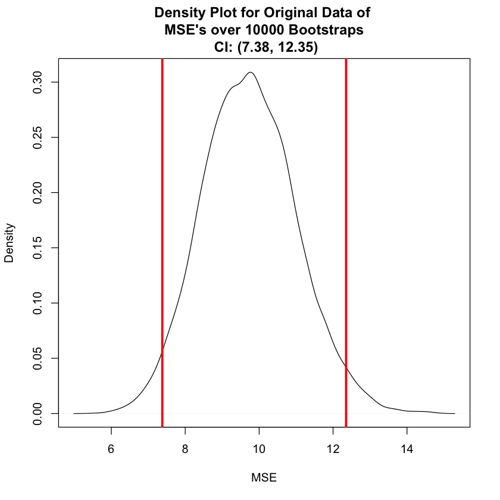

```r
#density plot
plot(density(MSE_error), main = "Density Plot for Original Data of \n MSE's over 10000 Bootstraps \n CI: (7.38, 12.35)", xlab = "MSE")
abline(v = ci.data, col = "red", lwd = 3)
```

A confidence interval of [7.38, 12.35] is pretty accurate because our data is scattered around the line of best fit which was found in another snippet of the code.